# Project 2: Business Statistics: Axis Insurance

### Context

Leveraging customer information is of paramount importance for most businesses. In the case of an insurance company, the attributes of customers like the ones mentioned below can be crucial in making business decisions. Hence, knowing to explore and generate value out of such data can be an invaluable skill to have.

### Objective

Statistical Analysis of Business Data. Explore the dataset and extract insights from the data. The idea is for you to get comfortable with doing statistical analysis in Python.

You are expected to do the following:

1. Explore the dataset and extract insights using Exploratory Data Analysis.
2. Prove (or disprove) that the medical claims made by the people who smoke is greater than those who don't? [Hint- Formulate a hypothesis and prove/disprove it]
3. Prove (or disprove) with statistical evidence that the BMI of females is different from that of males.
4. Is the proportion of smokers significantly different across different regions? [Hint : Create a contingency table/cross tab, Use the function : stats.chi2_contingency()]
5. Is the mean BMI of women with no children, one child, and two children the same? Explain your answer with statistical evidence.

*Consider a significance level of 0.05 for all tests.

### Data Dictionary

1. Age - This is an integer indicating the age of the primary beneficiary (excluding those above 64 years, since they are generally covered by the government).
2. Sex - This is the policy holder's gender, either male or female.
3. BMI - This is the body mass index (BMI), which provides a sense of how over or underweight a person is relative to their height. BMI is equal to weight (in kilograms) divided by height (in meters) squared. An ideal BMI is within the range of 18.5 to 24.9.
4. Children - This is an integer indicating the number of children/dependents covered by the insurance plan.
5. Smoker - This is yes or no depending on whether the insured regularly smokes tobacco.
6. Region - This is the beneficiary's place of residence in the U.S., divided into four geographic regions - northeast, southeast, southwest, or northwest.
7. Charges - Individual medical costs billed to health insurance

## Importing of Important Libraries

```python
#importing library to remove warnings

import warnings
warnings.filterwarnings('ignore')
```

```python
#import the important packages

import pandas as pd #library used for data manipulation and analysis
import numpy as np # library used for working with arrays.
import matplotlib.pyplot as plt # library for plots and visualisations
import seaborn as sns # library for visualisations
%matplotlib inline

import scipy.stats as stats # this library contains a large number of probability distributions as well as a growing library of statistical functions.
```

## Data Preparation

```python
#import the data into dataframe df

df = pd.read_csv('AxisInsurance.csv')
```

```python
#check the first 5 rows of data

df.head()
```

|  | age | sex | bmi | children | smoker | region | charges |
| --- | --- | --- | --- | --- | --- | --- | --- |
| 0 | 19 | female | 27.900 | 0 | yes | southwest | 16884.92400 |
| 1 | 18 | male | 33.770 | 1 | no | southeast | 1725.55230 |
| 2 | 28 | male | 33.000 | 3 | no | southeast | 4449.46200 |
| 3 | 33 | male | 22.705 | 0 | no | northwest | 21984.47061 |
| 4 | 32 | male | 28.880 | 0 | no | northwest | 3866.85520 |

```python
#check the last 5 rows of data

df.tail()
```

|  | age | sex | bmi | children | smoker | region | charges |
| --- | --- | --- | --- | --- | --- | --- | --- |
| 1333 | 50 | male | 30.97 | 3 | no | northwest | 10600.5483 |
| 1334 | 18 | female | 31.92 | 0 | no | northeast | 2205.9808 |
| 1335 | 18 | female | 36.85 | 0 | no | southeast | 1629.8335 |
| 1336 | 21 | female | 25.80 | 0 | no | southwest | 2007.9450 |
| 1337 | 61 | female | 29.07 | 0 | yes | northwest | 29141.3603 |

```python
#using the code to check if there's missing data or wrong data type

df.info()
```

```
<class 'pandas.core.frame.DataFrame'>
RangeIndex: 1338 entries, 0 to 1337
Data columns (total 7 columns):
 #   Column    Non-Null Count  Dtype
---  ------    --------------  -----
 0   age       1338 non-null   int64
 1   sex       1338 non-null   object
 2   bmi       1338 non-null   float64
 3   children  1338 non-null   int64
 4   smoker    1338 non-null   object
 5   region    1338 non-null   object
 6   charges   1338 non-null   float64
dtypes: float64(2), int64(2), object(3)
memory usage: 73.3+ KB
```

It can be seen that there are no missing data. Hence no adjustments need to be made to cater to missing data, but the object data type can be updated into category to save space. The other data types seems to be correct.

```python
#see how many rows and columns on dataframe

df.shape
```

```
(1338, 7)
```

```python
#converting object data to category

df['sex'] = df['sex'].astype("category")
df['smoker'] = df['smoker'].astype("category")
df['region'] = df['region'].astype("category")
df['children'] = df['children'].astype("category")
```

```python
#to check if the data type has been updated

df.info()
```

```
<class 'pandas.core.frame.DataFrame'>
RangeIndex: 1338 entries, 0 to 1337
Data columns (total 7 columns):
 #   Column    Non-Null Count  Dtype
---  ------    --------------  -----
 0   age       1338 non-null   int64
 1   sex       1338 non-null   category
 2   bmi       1338 non-null   float64
 3   children  1338 non-null   category
 4   smoker    1338 non-null   category
 5   region    1338 non-null   category
 6   charges   1338 non-null   float64
dtypes: category(4), float64(2), int64(1)
memory usage: 37.3 KB
```

```python
#to check the statistic of the columns

df.describe(include='all')
```

|  | age | sex | bmi | children | smoker | region | charges |
| --- | --- | --- | --- | --- | --- | --- | --- |
| count | 1338.000000 | 1338 | 1338.000000 | 1338.0 | 1338 | 1338 | 1338.000000 |
| unique | NaN | 2 | NaN | 6.0 | 2 | 4 | NaN |
| top | NaN | male | NaN | 0.0 | no | southeast | NaN |
| freq | NaN | 676 | NaN | 574.0 | 1064 | 364 | NaN |
| mean | 39.207025 | NaN | 30.663397 | NaN | NaN | NaN | 13270.422265 |
| std | 14.049960 | NaN | 6.098187 | NaN | NaN | NaN | 12110.011237 |
| min | 18.000000 | NaN | 15.960000 | NaN | NaN | NaN | 1121.873900 |
| 25% | 27.000000 | NaN | 26.296250 | NaN | NaN | NaN | 4740.287150 |
| 50% | 39.000000 | NaN | 30.400000 | NaN | NaN | NaN | 9382.033000 |
| 75% | 51.000000 | NaN | 34.693750 | NaN | NaN | NaN | 16639.912515 |
| max | 64.000000 | NaN | 53.130000 | NaN | NaN | NaN | 63770.428010 |

## Univariate Analysis of Categorical Variables

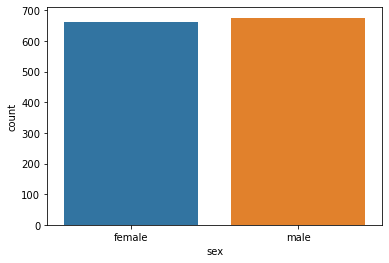

```python
#creating a count plot of sex

sns.countplot(df['sex'])
```

```python
#showing the count value of each unique category

df['sex'].value_counts()
```

```
male      676
female    662
Name: sex, dtype: int64
```

It can be seen that the number of female customers and male customers are about the same.

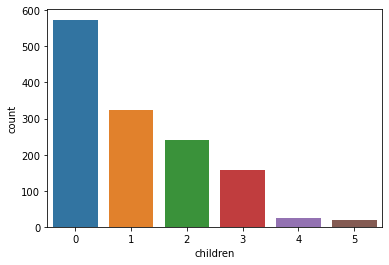

```python
#creating a count plot of number of children

sns.countplot(df['children'])
```

```python
#showing the count value of each unique category

df['children'].value_counts()
```

```
0    574
1    324
2    240
3    157
4     25
5     18
Name: children, dtype: int64
```

Most of the customers have 0 children (about 43% of data). It is followed by customers with only 1 children (about 24%) , and then customers with 2 children (about 18%).

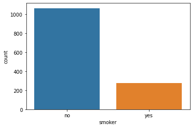

```python
#creating a count plot of smoker

sns.countplot(df['smoker'])
```

```python
#showing the count value of each unique category

df['smoker'].value_counts()
```

```
no     1064
yes     274
Name: smoker, dtype: int64
```

From the data, it can be seen that most of the customers are non-smokers, which account to almost 80% of the data.

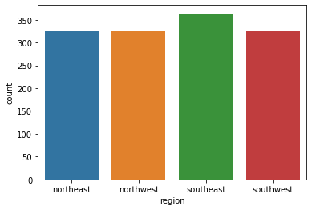

```python
#creating a count plot of region

sns.countplot(df['region'])
```

```python
#showing the count value of each unique category

df['region'].value_counts()
```

```
southeast    364
southwest    325
northwest    325
northeast    324
Name: region, dtype: int64
```

The data of the customers are divided into 4 categories : Northeast, Northwest, Southeast, and Southwest. The data are almost evenly spread, with slightly more customers who live on the Southeast region.

## Univariate Analysis of Numerical Data and Multivariate Analysis of Categorical vs Numerical Data

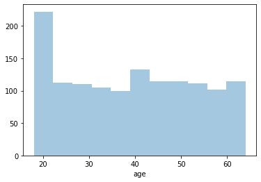

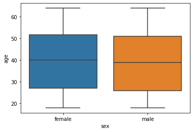

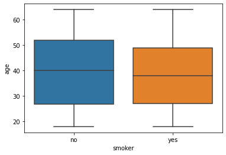

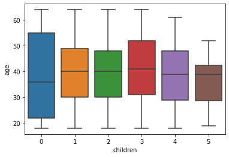

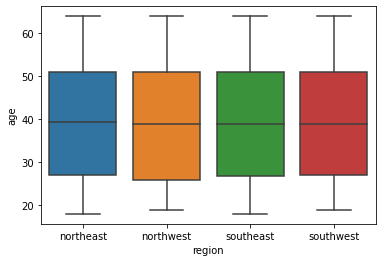

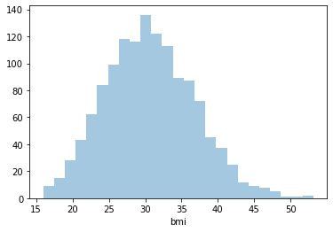

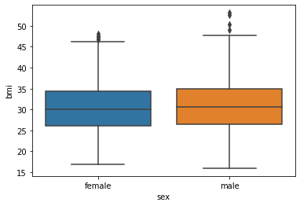

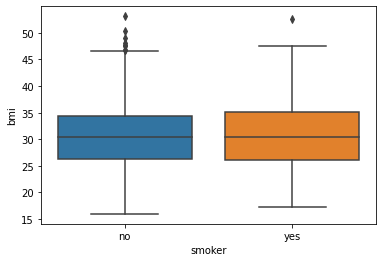

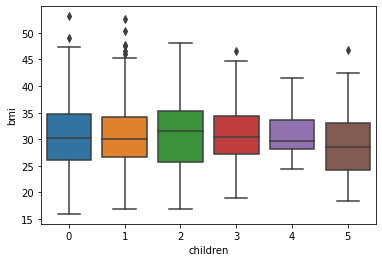

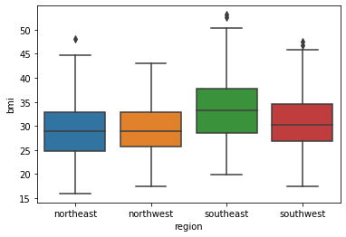

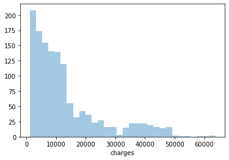

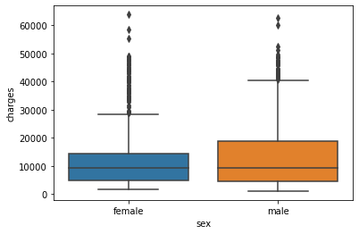

[3 more figures not shown]

```python
#the following code will create a histogram of a numerical column data followed by boxplots against categorical column

for i in df.columns:
    if type(df[i][0])!=str and i!='children':
        sns.distplot(df[i],kde=False)
        plt.show()
        sns.boxplot(data=df, x='sex', y=i)
        plt.show()
        sns.boxplot(data=df, x='smoker', y=i)
        plt.show()
        sns.boxplot(data=df, x='children', y=i)
        plt.show()
        sns.boxplot(data=df, x='region', y=i)
        plt.show()
```

From the various plots above, it can be inferred that:

1. The BMI of the customers seem to be normally distributed, as there are no skews.
2. The BMI of the customers on the southeast region are somewhat higher on average compared to customers from other regions.
3. The histogram for charges tend to be right skewed.
4. Smokers have higher charges than non-smokers.
5. The distribution of customers by age seemed to be almost uniform, with more customers with the age of 20 years old.

## Multivariate Analysis of Numerical vs Numerical Data

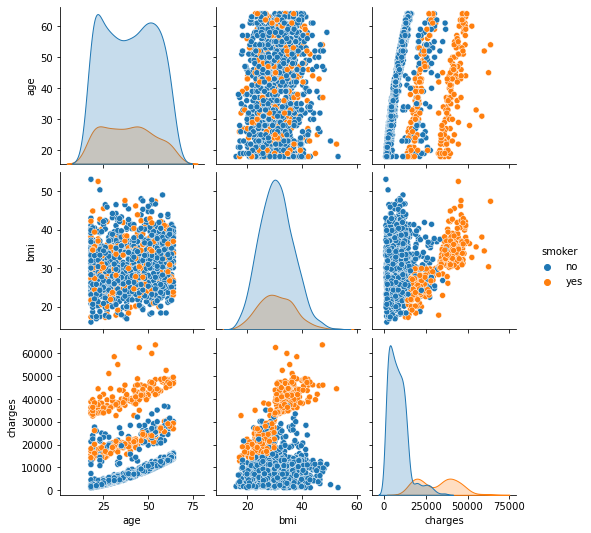

```python
#creating a pairplot between numerical variables while dividing data based on smoker/non-smoker

sns.pairplot(df, hue='smoker')
```

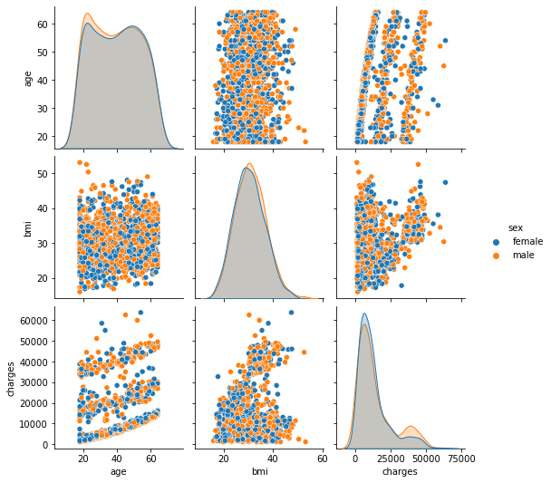

```python
#creating a pairplot between numerical variables while dividing data based on sex

sns.pairplot(df, hue='sex')
```

As per graph above, it can be seen that there are no significant difference of the data between male and female.

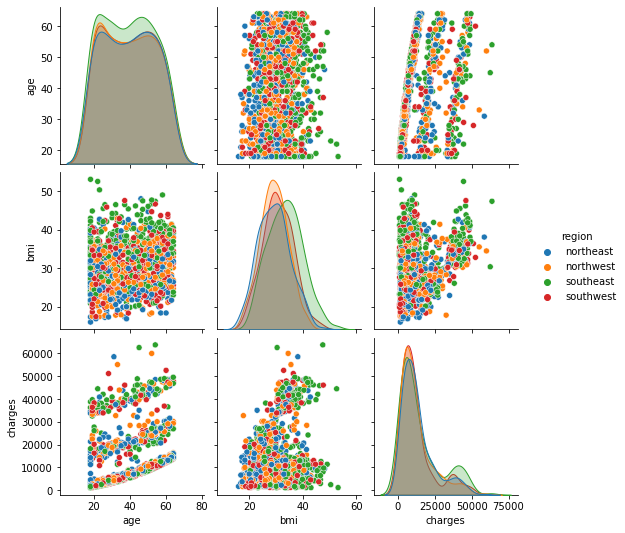

```python
#creating a pairplot between numerical variables while dividing data based on region

sns.pairplot(df, hue='region')
```

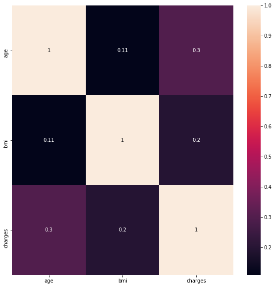

```python
#the following code will generate a heatmap between variables

plt.figure(figsize=(10,10))
sns.heatmap(df.corr(), annot=True)
```

There does not seem to be a strong correlation between the variables - the strongest correlation is between age and charges.

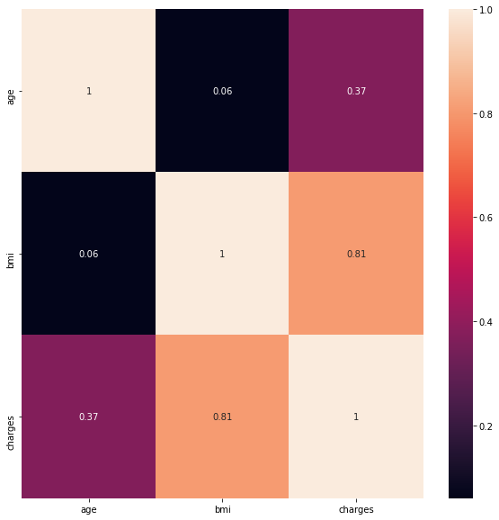

```python
#the following code will generate a heatmap between variables for smokers

plt.figure(figsize=(10,10))
sns.heatmap(df[df['smoker']=='yes'].corr(), annot=True)
```

For smokers, BMI and charges correlate greatly while age and charges somewhat correlates.

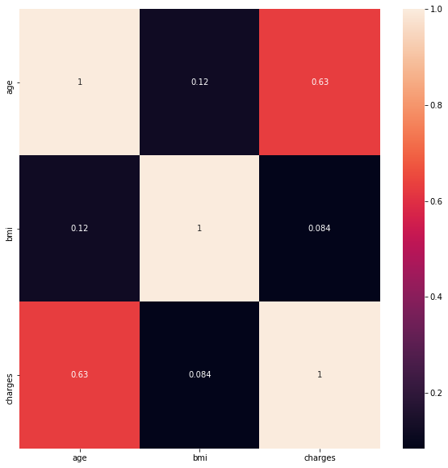

```python
#the following code will generate a heatmap between variables for non-smokers

plt.figure(figsize=(10,10))
sns.heatmap(df[df['smoker']=='no'].corr(), annot=True)
```

For non-smokers, age correlates with charges.

## Prove (or disprove) that the medical claims made by the people who smoke is greater than those who don't?

### Hypothesis Formulation

#### Null Hypothesis

> $H_0$: µ1 = µ2

#### Alternate hypothesis

> $H_a$: µ1 > µ2

where µ1 is medical claim for smoker and µ2 is medical claim for non-smoker

```python
#we need to see if the sample standard deviation for smokers differs from that for non-smokers

smstdev=df[df['smoker']=='yes']['charges'].std()
print ('Standard deviation of smoker data : ',smstdev)

nsmstdev=df[df['smoker']=='no']['charges'].std()
print ('Standard deviation of non-smoker data : ',nsmstdev)
```

```
Standard deviation of smoker data :  11541.547175589121
Standard deviation of non-smoker data :  5993.781819194933
```

```python
#we need to see the number of the samples we have

df['smoker'].value_counts()
```

```
no     1064
yes     274
Name: smoker, dtype: int64
```

### Confirmation of Assumptions

The assumptions are as below:

1. Based on the two data, the standard deviation between the two samples are different.
2. Sample size is more than 30, hence central limit theorem applies and normal distribution can be assumed.
3. The medical claims/charges data are continous.
4. The data between smokers and non-smokers are separate, hence independent.
5. Population mean and standard deviation are unknown.

Hence, we will use 'Two Independent Sample T-test for Equality of Means - Unequal Std Dev'

### Finding of p-value

```python
#import the required functions
from scipy.stats import ttest_ind

# find the p-value
test_stat, p_value = ttest_ind(df[df['smoker']=='yes']['charges'], df[df['smoker']=='no']['charges'], equal_var = False, alternative = 'greater')
print('p-value : ', p_value)
```

```
p-value :  2.94473222335849e-103
```

### Insight

The p-value is smaller than the level of significance of 0.05. Hence, we can reject the null hypothesis and prove that the medical claim for smokers is greater than non-smokers. The comparison can be seen as per below chart.

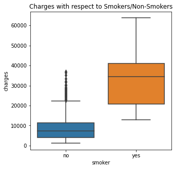

```python
#creating a boxplot for visualization

plt.figure(figsize=(5,5))
sns.boxplot(x='smoker', y='charges', data=df)
plt.title('Charges with respect to Smokers/Non-Smokers')
plt.show()
```

## Prove (or disprove) with statistical evidence that the BMI of females is different from that of males.

### Hypothesis Formulation

#### Null Hypothesis

> $H_0$: µ1 = µ2

#### Alternate hypothesis

> $H_a$: µ1 $\neq$ µ2

where µ1 is BMI of females and µ2 is BMI of males

```python
#we need to see if the sample standard deviation for female differs from male

fstdev=df[df['sex']=='female']['bmi'].std()
print ('Standard deviation of female data : ',fstdev)

mstdev=df[df['sex']=='male']['bmi'].std()
print ('Standard deviation of male data : ',mstdev)
```

```
Standard deviation of female data :  6.046023085745338
Standard deviation of male data :  6.140434615792248
```

```python
#we need to see the number of the samples we have

df['sex'].value_counts()
```

```
male      676
female    662
Name: sex, dtype: int64
```

### Confirmation of Assumptions

The assumptions are as below:

1. Based on the two data, the standard deviation between the two samples are similar.
2. Sample size is more than 30, hence central limit theorem applies and normal distribution can be assumed.
3. The BMI data is continous.
4. The data between female and male are separate, hence independent.
5. Population mean and standard deviation are unknown.

Hence, we will use 'Two Independent Sample T-test for Equality of Means - Equal Std Dev'

### Finding of p-value

```python
#import the required functions
from scipy.stats import ttest_ind

# find the p-value
test_stat, p_value = ttest_ind(df[df['sex']=='female']['bmi'], df[df['sex']=='male']['bmi'], equal_var = True, alternative = 'two-sided')
print('p-value : ', p_value)
```

```
p-value :  0.08997637178984934
```

### Insight

The p-value is larger than the level of significance of 0.05. Hence, we cannot reject the null hypothesis and we cannot prove that the BMI for females are different compared to BMI for males. The comparison can be seen as per below chart, and it can be seen that they are relatively similar.

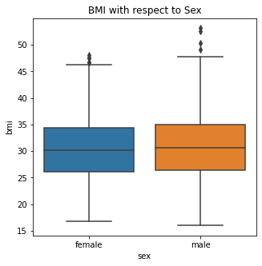

```python
#creating a boxplot for visualization

plt.figure(figsize=(5,5))
sns.boxplot(x='sex', y='bmi', data=df)
plt.title('BMI with respect to Sex')
plt.show()
```

## Is the proportion of smokers significantly different across different regions?

### Hypothesis Formulation

#### Null Hypothesis

> $H_0$: Proportion of smokers are independent across regions

#### Alternate hypothesis

> $H_a$: Propertion of smokers are not independent across regions

### Data Preparation for Testing

```python
#checking the count value of smoker by region

df.groupby(by=['smoker','region'])['region'].count()
```

```
smoker  region
no      northeast    257
        northwest    267
        southeast    273
        southwest    267
yes     northeast     67
        northwest     58
        southeast     91
        southwest     58
Name: region, dtype: int64
```

```python
#creating a table of count value of smoker by region

thattable = df[['smoker','region']].value_counts().unstack().copy()
```

```python
#printing the above mentioned table

thattable
```

| region smoker | northeast | northwest | southeast | southwest |
| --- | --- | --- | --- | --- |
| no | 257 | 267 | 273 | 267 |
| yes | 67 | 58 | 91 | 58 |

### Confirmation of Assumptions

The assumptions are as below:

1. Categorical variables are being compared
2. The expected value of the number of sample observations in each level of the variable is at least 5
3. Random sampling is done, as per the data provided

Hence, we will use 'Chi-Square Test for Independence'.

### Finding of p-value

```python
# import the required function
from scipy.stats import chi2_contingency

# find the p-value
chi, p_value, dof, expected = chi2_contingency(thattable)
print('The p-value is', p_value)
```

```
The p-value is 0.06171954839170547
```

### Insight

As the p-value is more than the significance level, we cannot reject the null hypothesis. Hence, we don't have enough statistical significance to conclude that proportion of smokers is not independent across regions at 5% significance level. Below are bar plots of number of smokers across different regions.

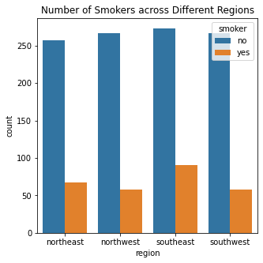

```python
#creating a boxplot for visualization using countplot

plt.figure(figsize=(5,5))
sns.countplot(data = df, x='region',hue='smoker')
plt.title('Number of Smokers across Different Regions')
plt.show()
```

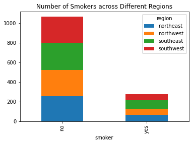

```python
#creating a boxplot for visualization to generate a stacked bar plot (smoker as x axis)

plt.figure(figsize=(5,5))
thattable.plot(kind='bar', stacked=True)
plt.title('Number of Smokers across Different Regions')
plt.show()
```

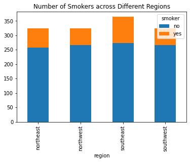

```python
#creating a boxplot for visualization to generate a stacked bar plot (region as x axis)

plt.figure(figsize=(5,5))
thattable.T.plot(kind='bar', stacked=True)
plt.title('Number of Smokers across Different Regions')
plt.show()
```

## Is the mean BMI of women with no children, one child, and two children the same? Explain your answer with statistical evidence.

### Filtering of Sample Data

```python
#creating a women only data

dffilter = df[df['sex']=='female'].copy()
```

```python
#checking if data are mostly female

dffilter.head()
```

|  | age | sex | bmi | children | smoker | region | charges |
| --- | --- | --- | --- | --- | --- | --- | --- |
| 0 | 19 | female | 27.90 | 0 | yes | southwest | 16884.92400 |
| 5 | 31 | female | 25.74 | 0 | no | southeast | 3756.62160 |
| 6 | 46 | female | 33.44 | 1 | no | southeast | 8240.58960 |
| 7 | 37 | female | 27.74 | 3 | no | northwest | 7281.50560 |
| 9 | 60 | female | 25.84 | 0 | no | northwest | 28923.13692 |

```python
#checking the bumber of children

dffilter['children'].value_counts()
```

```
0    289
1    158
2    119
3     77
4     11
5      8
Name: children, dtype: int64
```

### Hypothesis Formulation

#### Null Hypothesis

> $H_0$: $\mu_1 = \mu_2 = \mu_3$

#### Alternate Hypothesis

> $H_a$: At least one mean BMI level for woman with a number of children is different from the rest (for women with children of 0 to 2).

where $\mu_1$ is mean BMI of women with no children, $\mu_2$ is mean BMI of women with one child, and $\mu_3$ is mean BMI of women with two children

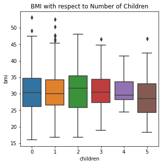

```python
# draw the boxplot for visualization

plt.figure(figsize=(5,5))
sns.boxplot(x='children', y = 'bmi' , data = df)
plt.title("BMI with respect to Number of Children")
plt.show()
```

It seems that as there are three groups of data that will be used, ANOVA is most likely used. However, the normality and equality of variance assumptions need to be checked.

1. For testing of normality, Shapiro-Wilk’s test is applied to the response variable.
2. For equality of varaince, Levene test is applied to the response variable.

### Shapiro-Wilk’s Test

#### Null Hypothesis

> $H_0:$ BMI follows a normal distribution

#### Alternative Hypothesis

> $H_a:$ BMI does not follow a normal distribution

```python
#changing the children data type for ease of filtering on upcoming code

dffilter['children'] = dffilter['children'].astype("int64")
```

```python
#checking of data type

dffilter.info()
```

```
<class 'pandas.core.frame.DataFrame'>
Int64Index: 662 entries, 0 to 1337
Data columns (total 7 columns):
 #   Column    Non-Null Count  Dtype
---  ------    --------------  -----
 0   age       662 non-null    int64
 1   sex       662 non-null    category
 2   bmi       662 non-null    float64
 3   children  662 non-null    int64
 4   smoker    662 non-null    category
 5   region    662 non-null    category
 6   charges   662 non-null    float64
dtypes: category(3), float64(2), int64(2)
memory usage: 28.2 KB
```

```python
# import the required function
from scipy import stats

# find the p-value
w, p_value = stats.shapiro(dffilter[dffilter['children']<3]['bmi'])
print('The p-value is', p_value)
```

```
The p-value is 0.010864038951694965
```

The p-value is less than the significant level of 0.05. Hence the null hypothesis can be rejected and it can be said that BMI does not follow a normal distribution. However, the ANOVA test can tolerate violations to the normality assumption rather well and hence we can still proceed to use ANOVA.

### Levene’s Test

#### Null Hypothesis

> $H_0$: All the population variances are equal

#### Alternative Hypothesis

> $H_a$: At least one variance is different from the rest

```python
#import the required function
from scipy.stats import levene
statistic, p_value = levene(dffilter['bmi'][dffilter['children']==0],
                                   dffilter['bmi'][dffilter['children']==1],
                                   dffilter['bmi'][dffilter['children']==2])
# find the p-value
print('The p-value is', p_value)
```

```
The p-value is 0.3899432394522804
```

The p-value is more than the significant level value of 0.05. Hence the null hypothesis cannot be rejected, and we can conclude that all the population variances between the number of children from 0 to 2 for women are equal.

### Confirmation of Assumptions

The assumptions are as below:

1. Using the Levene's test, population variances are found to be equal.
2. The data samples are independent simple random variables.
3. Using the Shapiro-Wilk's test, the distribution is found to be not normal. However, there are more other assumptions that support the use of ANOVA, and ANOVA can tolerate violations to the normality assumption.

### Finding of p-value

```python
#import the required function
from scipy.stats import f_oneway

# perform one-way anova test
test_stat, p_value = f_oneway(dffilter.loc[dffilter['children'] == 0, 'bmi'],
                              dffilter.loc[dffilter['children'] == 1, 'bmi'],
                              dffilter.loc[dffilter['children'] == 2, 'bmi'])
print('The p-value is ' + str(p_value))
```

```
The p-value is 0.7158579926754841
```

### Insight

As the p-value larger than the significance level of 0.05, we cannot reject the null hypothesis. Hence, we do not have enough statistical significance to conclude that at least one mean BMI level for woman with a specific number of children is different from the rest (for women with children of 0 to 2).